# Homework 4

### Regression: Population vs. Votes

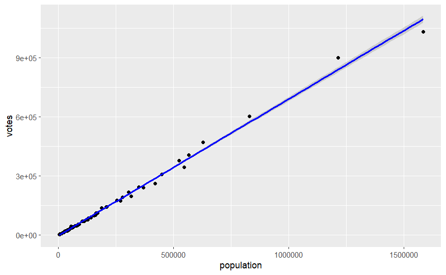

```r
# The higher the population, the more voters. No shocker
ggplot(df, aes(x = population, y = votes)) +
  geom_point() +
  stat_smooth(method = "lm", col = "blue")
```

In the regression of population vs votes, we see that as the population increases, so does the number of voters, shown by the positive slope. The data points seem to fit the line very well with no distinct outliers. This is to be expected, since a higher county population means more people who can become voters.

There is an apparent collinearity in these values; both income and population seem to have a positive affect on the number of registered voters in the county. However, since we logically know that a larger population will produce more registered voters, a single variable regression of income and voters will be sufficient.

### Summary: Random Sampling of Data

```r
set.seed(777)
library(rsample)
data_split <- initial_split(df, prop = .8)
data_train <- training(data_split)
data_test  <- testing(data_split)

trainmodel <- lm(votes~income + population, data=data_train)
testmodel <- lm(votes ~ income + population, data=data_test)
summary(trainmodel)
```

```
Call:
lm(formula = votes ~ income + population, data = data_train)

Residuals:
   Min     1Q Median     3Q    Max
-42142  -2567   1073   3681  29237

Coefficients:
              Estimate Std. Error t value Pr(>|t|)
(Intercept) -2.613e+04  1.115e+04  -2.343   0.0231 *
income       3.729e-01  2.194e-01   1.699   0.0954 .
population   7.162e-01  9.133e-03  78.421   <2e-16 ***
---
Signif. codes:  0 ‘***’ 0.001 ‘**’ 0.01 ‘*’ 0.05 ‘.’ 0.1 ‘ ’ 1

Residual standard error: 9991 on 50 degrees of freedom
Multiple R-squared:  0.9965,    Adjusted R-squared:  0.9964
F-statistic:  7133 on 2 and 50 DF,  p-value: < 2.2e-16
```

```r
summary(testmodel)
```

```
Call:
lm(formula = votes ~ income + population, data = data_test)

Residuals:
   Min     1Q Median     3Q    Max
-16264  -1480   -390   1226  13107

Coefficients:
              Estimate Std. Error t value Pr(>|t|)
(Intercept) -4.571e+04  9.445e+03  -4.839 0.000520 ***
income       8.623e-01  1.714e-01   5.030 0.000384 ***
population   6.482e-01  4.965e-03 130.542  < 2e-16 ***
---
Signif. codes:  0 ‘***’ 0.001 ‘**’ 0.01 ‘*’ 0.05 ‘.’ 0.1 ‘ ’ 1

Residual standard error: 6780 on 11 degrees of freedom
Multiple R-squared:  0.9995,    Adjusted R-squared:  0.9994
F-statistic: 1.026e+04 on 2 and 11 DF,  p-value: < 2.2e-16
```

```r
predict(testmodel, newdata = data_split, interval = 'confidence')
```

```
          fit         lwr        upr
1   18219.426  13410.6801  23028.171
2   69136.527  64735.9569  73537.097
3   27068.712  22239.5139  31897.910
4   22254.699  17256.2488  27253.150
5   32725.791  28056.4955  37395.086
6   39667.774  34860.8766  44474.671
7    4041.648   -846.2753   8929.571
8  134006.179 128007.3357 140005.022
9   30845.208  26044.4269  35645.990
10 174612.302 170378.1682 178846.436
11 433114.478 423080.7259 443148.229
12  21986.487  17017.9705  26955.004
13 109228.342 105042.8246 113413.860
14  24305.015  19478.3358  29131.694
```

[output cut: 39 more lines]

### Training Model Regression: Income vs. Votes

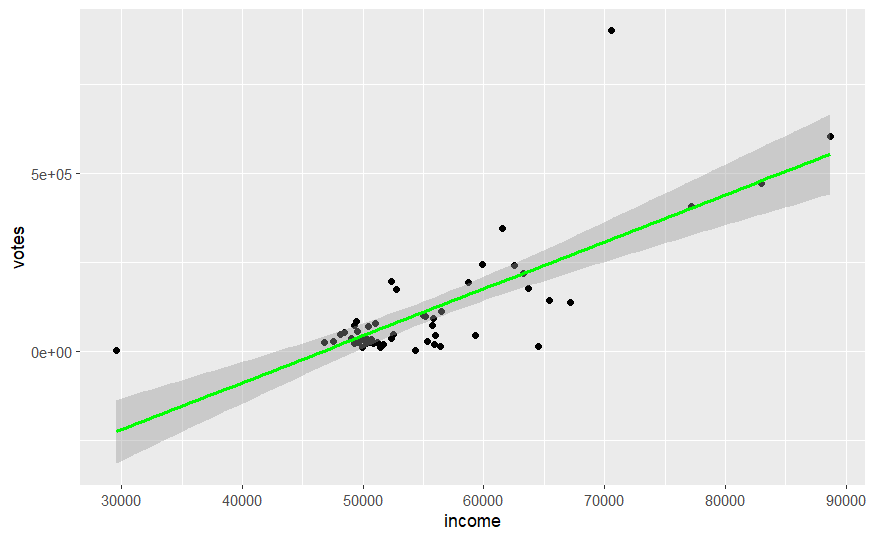

```r
# Testing model regression - underfit or overfit?
ggplot(trainmodel, aes(x = income, y = votes)) +
  geom_point() +
  stat_smooth(method = "lm", col = "green")
```

### Testing Model Regression

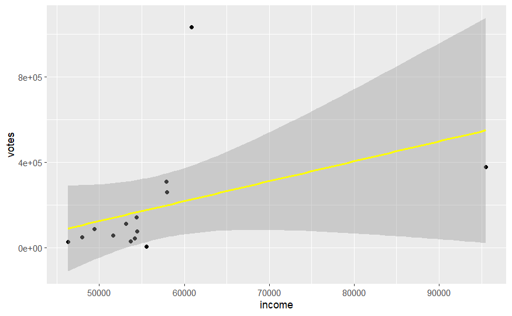

```r
ggplot(testmodel, aes(x = income, y = votes)) +
  geom_point() +
  stat_smooth(method = "lm", col = "yellow")
```

Looking at the training model, we would say that it is a good fit, neither underfitting nor overfitting. However, the case is less clear for the test result. The test result underfits the original income vs votes regression, because it does not demonstrate as strong as a correlation in its slope. This is likely due to there being less data points available on this model. The point at income just above 60,000 is a noticeable outlier, likely caused by insufficient training.